# Unsupervised Learning: Clustering and PCA

Machine Learning Group Assignment

machine learning

Author

David Rios, Elena Ortiz, Fiona Godsill, and Lily Morgan

Published

April 1, 2025

This ML project applies unsupervised machine learning techniques—clustering and PCA—to analyze the musical features of Justin Bieber’s top hits!

# Research Goals

> Our goal for this project is to explore and summarize Justin Bieber’s most successful songs that have been played on our Belieber Nation radio station. Specifically, we aim to identify the musical traits and popularity trends that set his biggest hits apart. By examining patterns across his top tracks, we hope to understand better what resonates most with listeners and use that insight to make smarter, more targeted programming decisions in the future.

# Data

> Our training data focuses on the Billboard chart performance and musical features of Justin Bieber’s songs. We started with a larger dataset of 27 artists and filtered it down to just Bieber’s tracks to fit our project goal at the Belieber Nation radio station. Each song includes detailed features such as danceability, energy, and tempo. Other variables like duration (in milliseconds), loudness, and instrumentalness give us more insight into the sound and structure of each song. We also have two key indicators: Spotify popularity score and the number of weeks the song spent on the Billboard charts. All the data reflects Justin Bieber’s popularity across the United States, covering a time range that captures major milestones in his career. We are using this data to better understand what musical qualities define his biggest hits, to make smarter programming choices, and keep our beloved Beliebers tuning in.

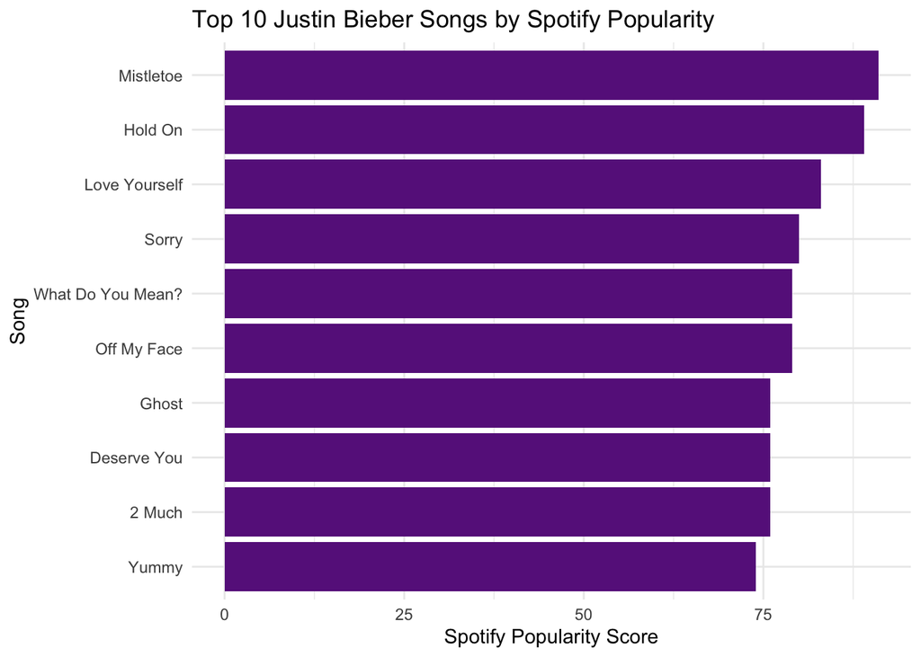

# Cluster Analysis

## Implementation

See code below for full details.

**View Code**

```r
# Include all clustering code in here.
# Make sure to include comments explaining what your code does.

#Model building with 4 clusters
set.seed(253)
k_4 <- kmeans(scale(my_artist), centers = 4)

#Cluster output
cluster_data <- my_artist %>%
  mutate(kmeans_cluster_k = as.factor(k_4$cluster)) %>%
  group_by(kmeans_cluster_k) %>%
  summarize_all(mean)
```

## Insights

> Then, we ran a hierarchical model. Our hierarchical model showed a lot of variation within clusters for the heat map which did not allow a lot of opportunities for interpretation. Also, if we had more than 2 clusters, the model would create a cluster with a single song. This once again limited interpretation. Ultimately, we chose to run a K-means clustering model. Overall, K-means allowed for more analysis to understand what traits contributed to Justin Bieber’s most popular songs.

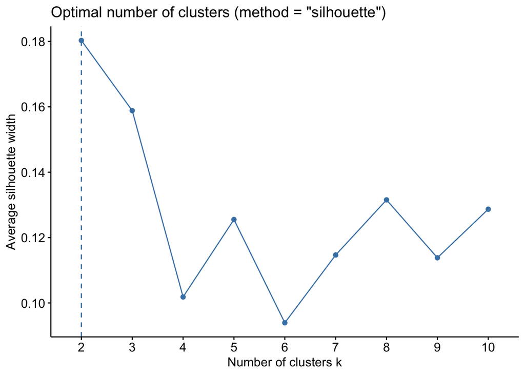

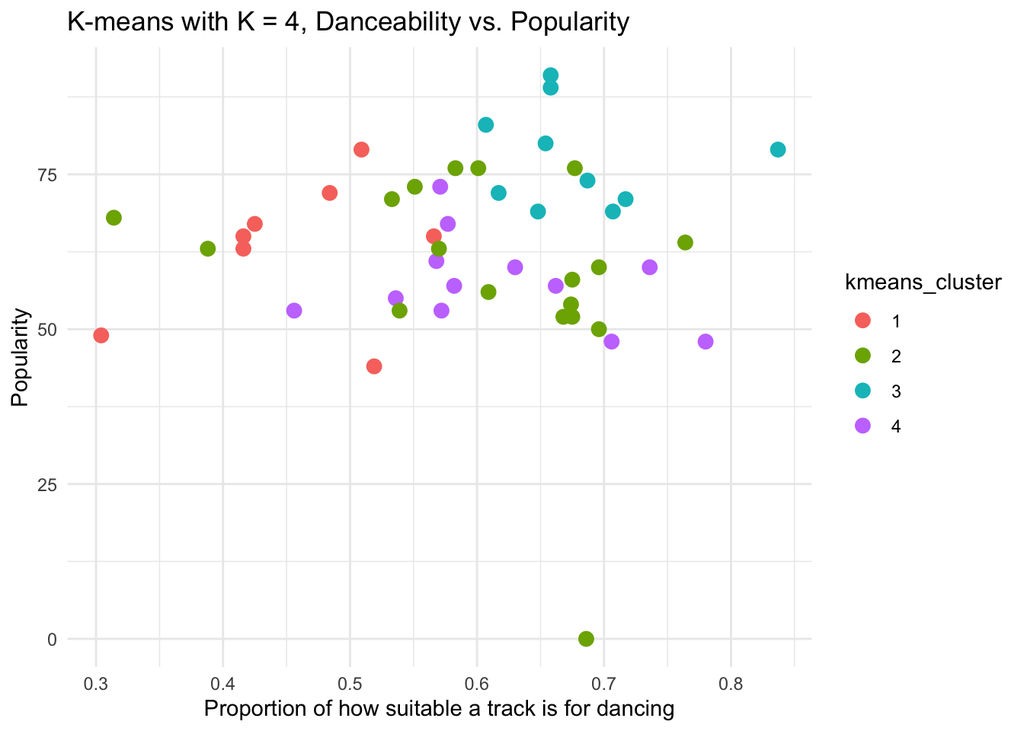

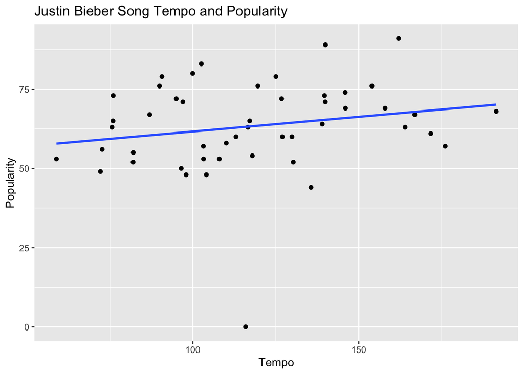

# Dimension Reduction

## Implementation

See code below for full details.

**View Code**

```r
# Include all dimension reduction code in here.
# Make sure to include comments explaining what your code does.

#Remove outcomes
my_artist_2 <- my_artist %>%
select(where(is.numeric)) %>%
select(-spotify_popularity, -billboard_weeks)

pca_justin <- prcomp(my_artist_2, scale = TRUE, center = TRUE)
```

## Insights

> There is a wide variety of songs – some go viral on TikTok let’s say; hence, they become popular. Others are, although, rich in content and they are not as famous as one could expect. Thus, given the wide variety of predictors and the insights each gives us we applies a ML technique called Principal Component Analysis (PCA). There is a whole bunch of fancy math that goes behind PCA, but just keep in mind that PCA explores patterns in group structures in our columns. While doing this, it is hard to interpret but with the help of your Belieber wizards, we are going to help you disantagle this mysterty of JB’s hits. Let’s explore some graphs to help you understand PCAs.
> 1. Given that we want to know how many overall PCAs we should use, we first implement a graph of Cumulative % of variance explained (plot) versus the number of PCs. As you can see, if we only use 1 PC, we can only explain roughly 25% of the variability in JB’s most popular songs – this in nature is our strongest way to go as the variables that are being merged are correlated the most. Nonetheless, we may want to explain a bit more of the variability of the popular songs.
> 2. Now, let’s get our hands dirty! This circle plot (called a PCA variable plot) shows how much each musical feature contributes to the first PC (x-axis) and the second PC (y-axis). The main takeaway from this graph is that energy, loudness, and danceability are strongly aligned with PC1. This tells us that PC1 is capturing the “power” or “performance energy” of a song. On the other side, acousticness is pointing in the opposite direction, which means it’s negatively correlated with energy and loudness, the more acoustic a song is, the less energetic and loud it tends to be. PC2 appears to be shaped more by speechiness, duration, and key, which tell us that this component captures songs with longer durations or more spoken lyrical content. To sum all this up, PC1 separates songs by how upbeat and energetic they are, and PC2 adds a layer that reflects structure, vocal delivery, and complexity.
> 3. Don’t feel overwhelmed, we know that you want to explore the underlying reasons behind JB’s most popular songs and this requires attention to detail ;). This is our last plot, although PC1 and PC2 explain a good amount of the variability, we might want to consider more PCs, and I would suggest using 4 PCs, because we want to make sure to tackle little details of each song and be careful, but also we want to save you some money and save us the computation expense, we don’t want to overwhelm you, our beloved music manager, so we will use 4PCs, which each shapes the song with their variable as you can see. Note: if the variable bar is above 0 (pointing upwards) it means that it contributes positively and the magnitude of it depends on the height of it, and same if the bar points below 0.

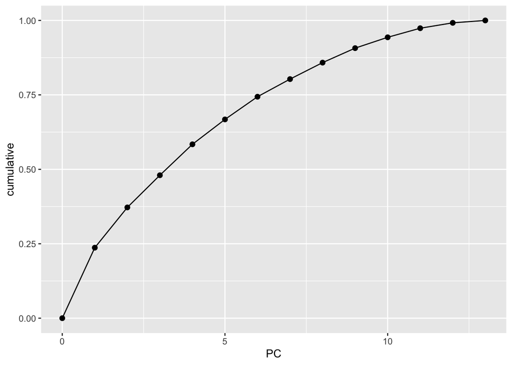

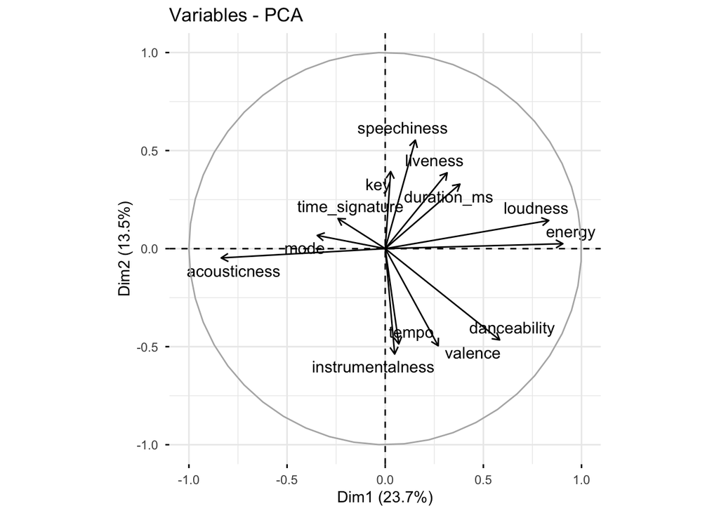

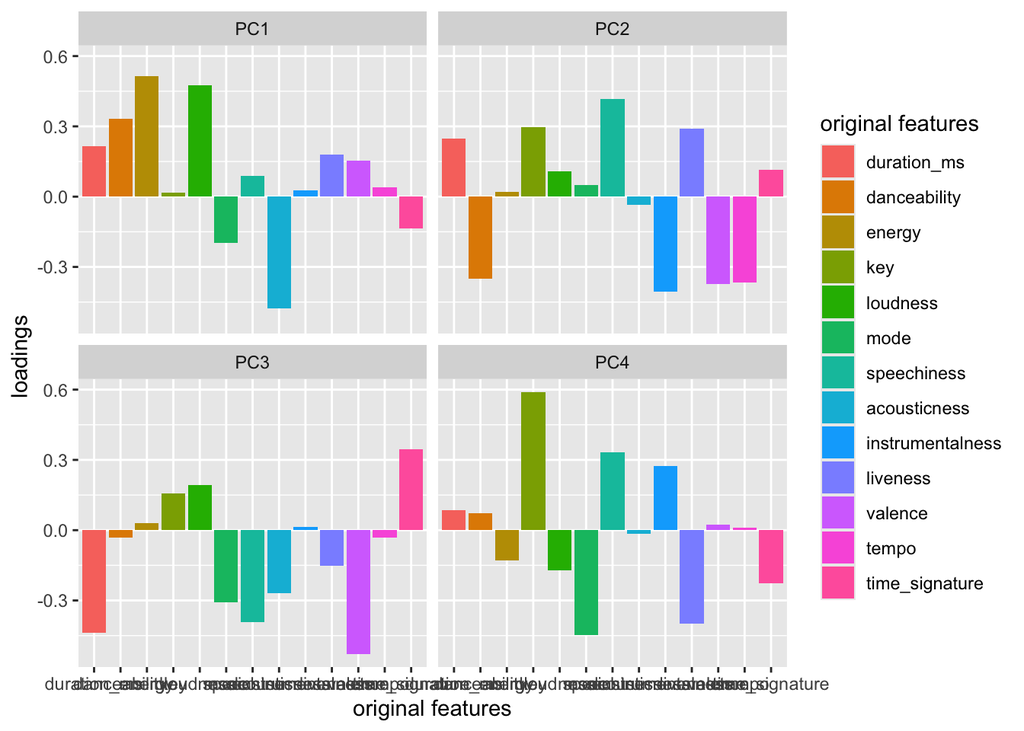

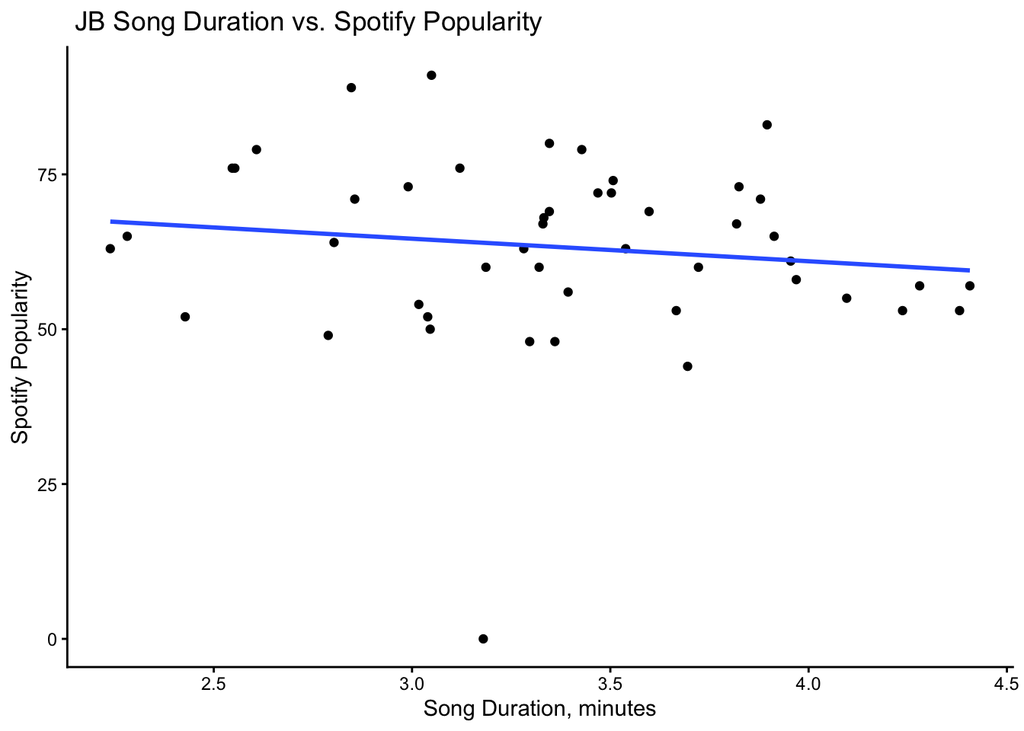

# Conclusions

> After diving deep into Justin Bieber’s chart-toppers, our analysis uncovered what gives his biggest hits their magic. Using unsupervised learning tools like K-means clustering and PCA, we spotted clear patterns: Bieber’s most successful tracks are high in energy, danceability, and tempo. Basically, if it makes you want to get up and dance, it probably did well on the charts. On the flip side, songs that were more acoustic, chill, or heavy on instrumentals were appreciated by die-hard fans but didn’t exactly dominate the Billboard. In short, the data confirms what your ears probably already know—Beliebers love a good beat.

> While our models provided valuable insights, there are limitations to consider. First, some of our clusters showed minimal variation in popularity, making interpretation more challenging. Also, the dataset only includes measurable audio features and does not capture external factors that influence success, such as social media trends or collaborations. Finally, PCA helped reduce complexity but interpreted it more abstractly. Still, this analysis provides a data-driven lens on what makes a hit Bieber track, and we recommend focusing airtime on songs that fit the high-energy, danceable profile, especially when appealing to casual listeners or planning peak-hour playlists. Looking ahead, this kind of analysis isn’t just useful for understanding Bieber’s back catalog—it could help us predict the next big bop before it even drops. We could use the same approach to compare different artists or track how an artist’s sound evolves (hello genre-hopping era!). If we start combining this musical data with things like TikTok trends or skip rates, we might just crack the code for the perfect radio hit—and maybe even beat the charts to it. Who needs a crystal ball when you’ve got clustering algorithms?

# Appendix

```r
# Heat maps: ordered by the id variable (not clustering)
heatmap(scale(data.matrix(my_artist)), Colv = NA, Rowv = NA)

#Make hierarchical model
hier_model <- hclust(dist(scale(my_artist)), method = "complete")

# Heat maps: ordered by dendrogram / clustering
heatmap(scale(data.matrix(my_artist)), Colv = NA)

# Dendrogram (change font size w/ cex)
fviz_dend(hier_model, horiz = TRUE, cex = .25)

# Assign each sample case to a cluster
cluster_data_hier <- my_artist %>%
  mutate(hier_cluster_k = as.factor(cutree(hier_model, k = 2))) %>%
  group_by(hier_cluster_k) %>%
  summarize_all(mean)

#Visualize cluster
cluster_data_hier

# Visualize the clusters on the dendrogram (change font size w/ cex)
fviz_dend(hier_model, k = 2, cex = .25)
fviz_dend(hier_model, k = 2, horiz = TRUE, cex = .25)

#PCA
pca_justin$rotation[, 1:4]
```